# Red Wine Quality by Michal Masika

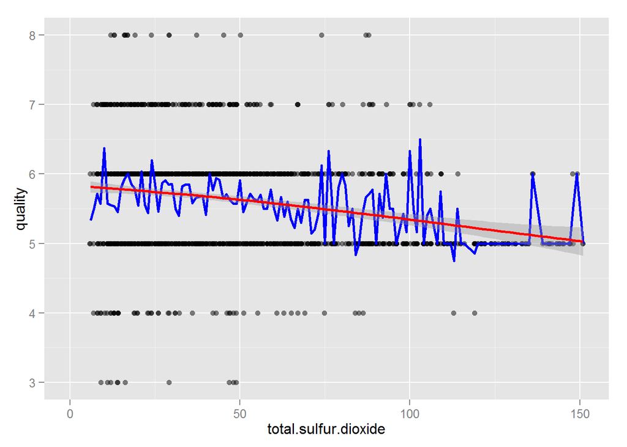

```
##
##  Pearson's product-moment correlation
##
## data:  quality and total.sulfur.dioxide
## t = -7.5271, df = 1597, p-value = 8.622e-14
## alternative hypothesis: true correlation is not equal to 0
## 95 percent confidence interval:
##  -0.2320162 -0.1373252
## sample estimates:
##        cor
## -0.1851003
```

By excluding the outliers (observations with very high amount of total sulfur dioxide), the figure above suggests that there is a negative relationship between sulfur dioxide and the quality. The correlation is - 0.18. Note that I used for this analysis the total sulfur dioxide instead of free sulfur dioxide as there is a very strong relationship between those two variables with correlation 0.67. As next I examine the impact of amount of chlorides.

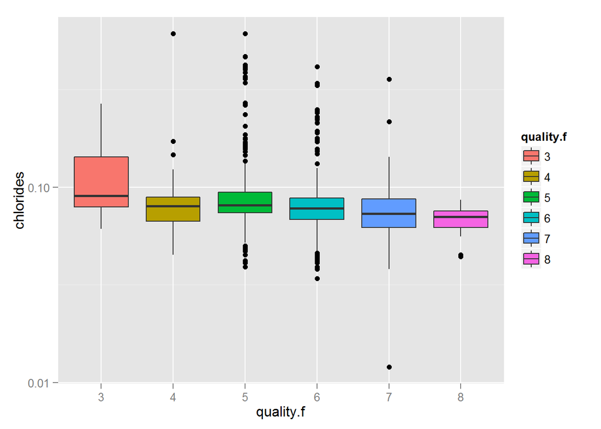

```
## geom_smooth: method="auto" and size of largest group is >=1000, so using gam with formula: y ~ s(x, bs = "cs"). Use 'method = x' to change the smoothing method.
```

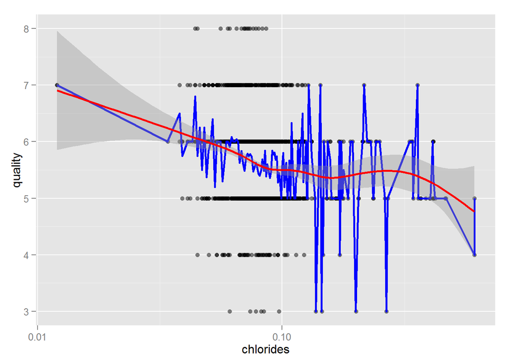

```
## geom_smooth: method="auto" and size of largest group is >=1000, so using gam with formula: y ~ s(x, bs = "cs"). Use 'method = x' to change the smoothing method.
```

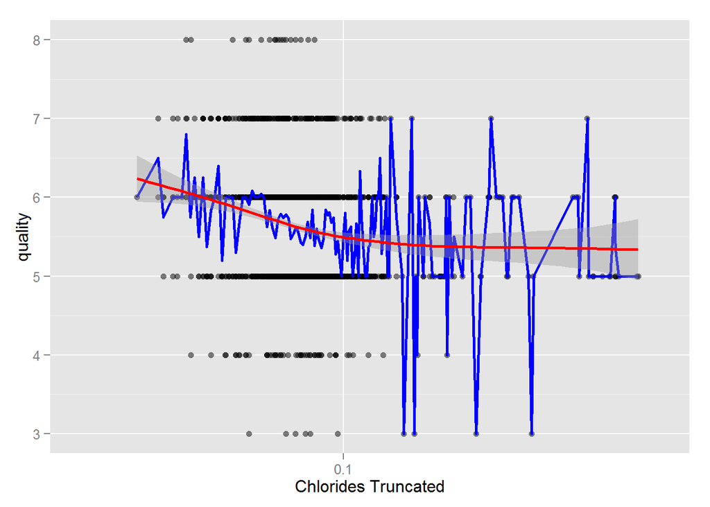

```
##
##  Pearson's product-moment correlation
##
## data:  quality and log10(chlorides)
## t = -7.1508, df = 1597, p-value = 1.308e-12
## alternative hypothesis: true correlation is not equal to 0
## 95 percent confidence interval:
##  -0.2232336 -0.1282260
## sample estimates:
##      cor
## -0.17614
```

In the first moment, the relationship between chlorides and quality seems to be clearly negative. However, if we exclude the outliers (0.1 % of observations with the lowest and highest amount of chlorides), the figure suggestst that the relationship is negative but not that strong. Actually, when the amount of chlorides is large enough, the negative correlation more or less disappear.

According to correlation matrix, alcohol seems to have the strongest relationship with the quality.

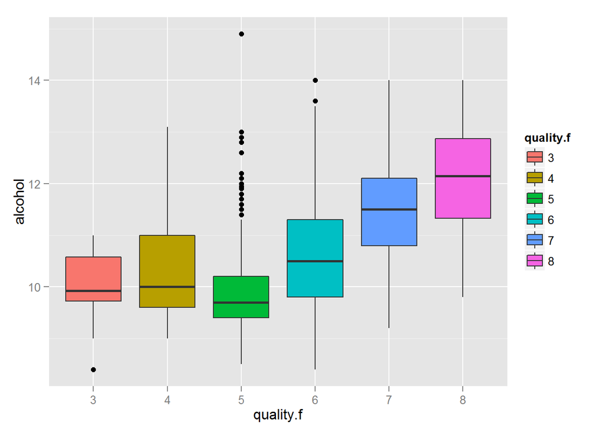

```
## geom_smooth: method="auto" and size of largest group is >=1000, so using gam with formula: y ~ s(x, bs = "cs"). Use 'method = x' to change the smoothing method.
```

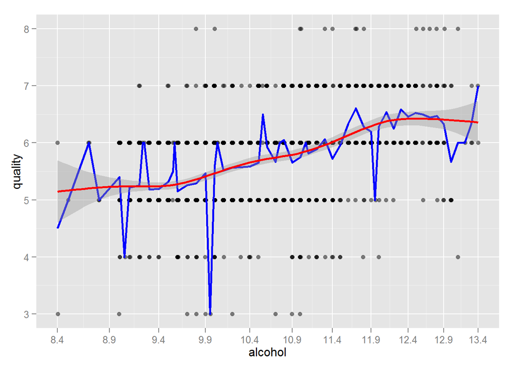

```
##
##  Pearson's product-moment correlation
##
## data:  quality and log10(alcohol)
## t = 21.687, df = 1597, p-value < 2.2e-16
## alternative hypothesis: true correlation is not equal to 0
## 95 percent confidence interval:
##  0.4382062 0.5139842
## sample estimates:
##       cor
## 0.4769811
```

The correlation between alcohol and quality is positive and pretty strong (0.47). By examining the figure you can see that the relationship is not that strong by wines with very low and very high amount of alcohol, respectively. More specifically, the relationship by wines with alcohol lower than 9.5 and wines with alcohol larger than 12 seems to be very flat. This might be also driven by the fact that there are not so many observations in both lower and higher region. I can examine this relationship a little bit differently, so that I create a categorical alcohol variable (“low”< 9.5, “high”>=11.5, “mid” - remaining observations).

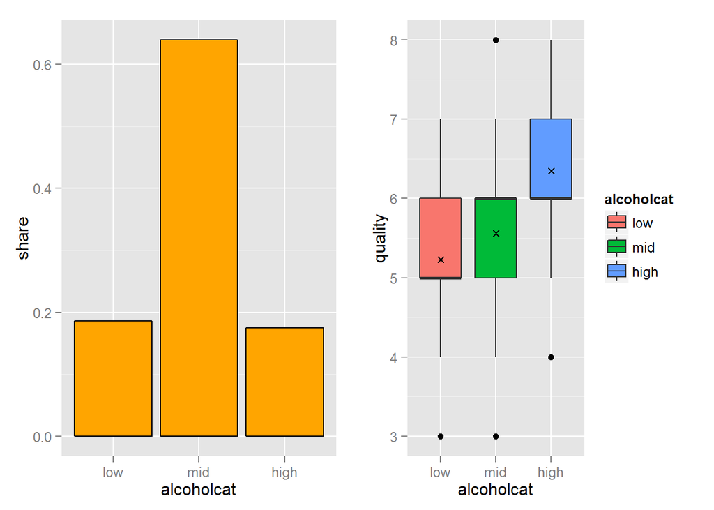

```
## data$alcoholcat: low
##    Min. 1st Qu.  Median    Mean 3rd Qu.    Max.
##   3.000   5.000   5.000   5.229   6.000   7.000
## --------------------------------------------------------
## data$alcoholcat: mid
##    Min. 1st Qu.  Median    Mean 3rd Qu.    Max.
##    3.00    5.00    6.00    5.56    6.00    8.00
## --------------------------------------------------------
## data$alcoholcat: high
##    Min. 1st Qu.  Median    Mean 3rd Qu.    Max.
##   4.000   6.000   6.000   6.346   7.000   8.000
```

More than 60% of observations are in mid category. The boxplot suggests that with the higher amount of alcohol the average quality is increasing (5.23 -> 5.56 -> 6.35). In the last step I look at the density variable.

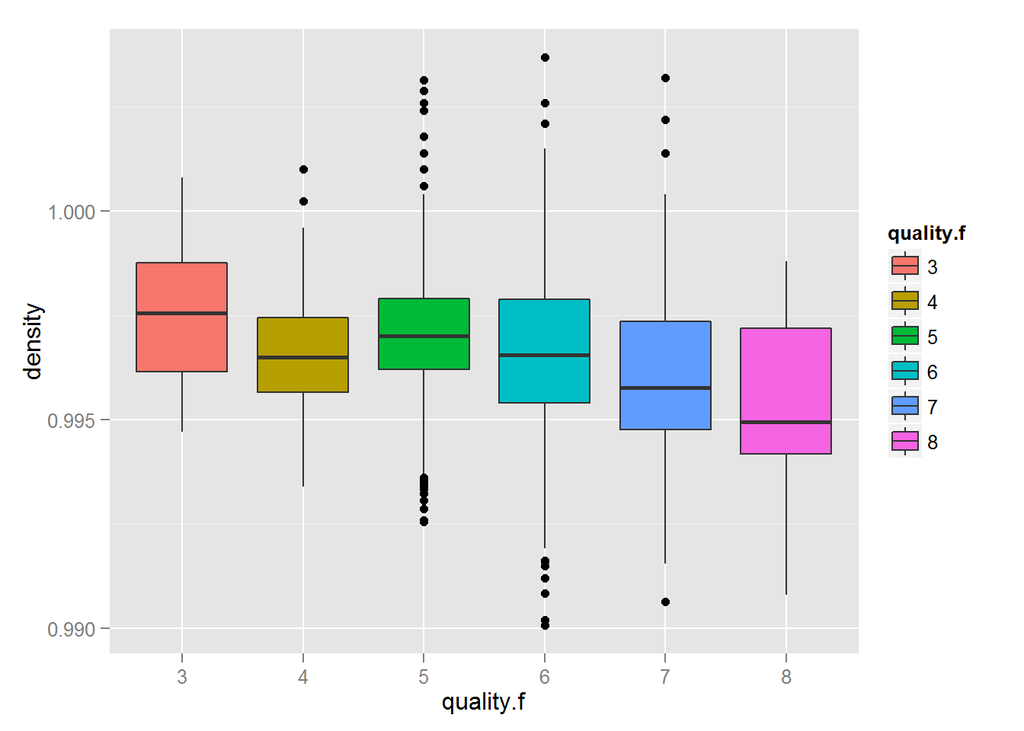

```
## geom_smooth: method="auto" and size of largest group is >=1000, so using gam with formula: y ~ s(x, bs = "cs"). Use 'method = x' to change the smoothing method.
```

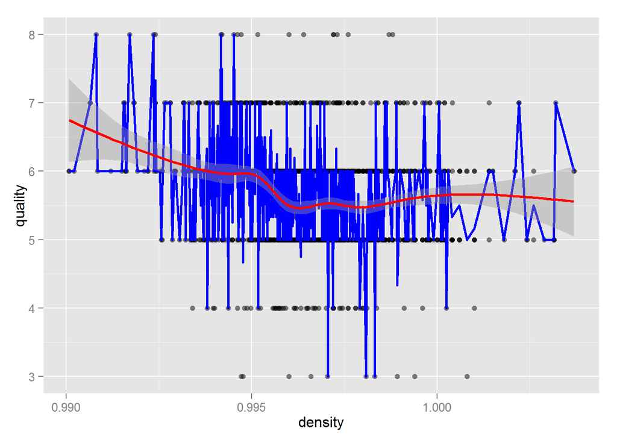

```
##
##  Pearson's product-moment correlation
##
## data:  quality and density
## t = -7.0997, df = 1597, p-value = 1.875e-12
## alternative hypothesis: true correlation is not equal to 0
## 95 percent confidence interval:
##  -0.2220365 -0.1269870
## sample estimates:
##        cor
## -0.1749192
```

The figures suggest that there is a weak negative relationship between density and quality. The previous analysis showed that the density variable might correlate with other variables (e.g.fixed acidity, citric acidity, residual sugar or alcohol). So let’s look at the bivariate plots.

```
## geom_smooth: method="auto" and size of largest group is >=1000, so using gam with formula: y ~ s(x, bs = "cs"). Use 'method = x' to change the smoothing method.
```

```
## geom_smooth: method="auto" and size of largest group is >=1000, so using gam with formula: y ~ s(x, bs = "cs"). Use 'method = x' to change the smoothing method.
```

```
## geom_smooth: method="auto" and size of largest group is >=1000, so using gam with formula: y ~ s(x, bs = "cs"). Use 'method = x' to change the smoothing method.
```

```
## geom_smooth: method="auto" and size of largest group is >=1000, so using gam with formula: y ~ s(x, bs = "cs"). Use 'method = x' to change the smoothing method.
```

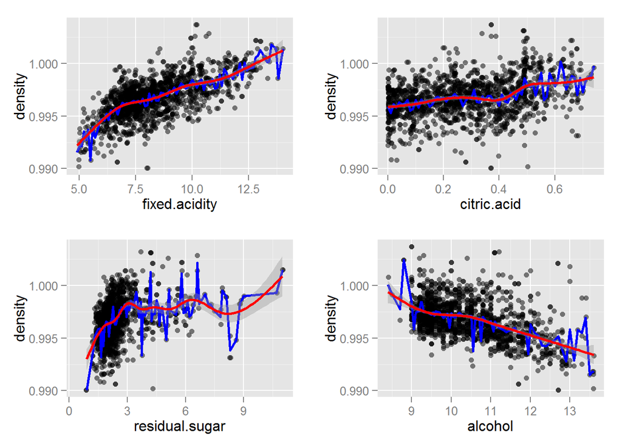

While the density variable is negatively correlated with alcohol, the relationship between density and fixed acidity, citric acid and residual sugar seems to be positiv, with the strongest relationship between fixed acidity and density. For observations with residual sugar between 0 and 3 it seems that residual sugar hast very strong positive impact on density. For observations with higher amount of sugar this relationship is much weaker.

```
##
## Calls:
## m1: lm(formula = density ~ fixed.acidity + citric.acid + residual.sugar +
##     alcohol, data = subset(data, data$residual.sugar <= quantile(data$residual.sugar,
##     0.99, na.rm = TRUE)))
##
## ==========================
## (Intercept)      0.999***
##                 (0.000)
## fixed.acidity    0.001***
##                 (0.000)
## citric.acid     -0.001**
##                 (0.000)
## residual.sugar   0.001***
##                 (0.000)
## alcohol         -0.001***
##                 (0.000)
## --------------------------
## R-squared            0.749
## adj. R-squared       0.748
## sigma                0.001
## F                 1174.462
## p                    0.000
## Log-likelihood    8806.486
## Deviance             0.001
## AIC             -17600.972
## BIC             -17568.770
## N                 1583
## ==========================
```

By estimating simple linear model with density as dependent variable and fixed acidity, citric acid, residual sugar and alcohol as explanatory variable, you can easily see that variation in these 4 variables can explain almost 75% variation in density. You can see a negative coefficient by citric acid. You might wonder how this fit together with the observed positive relationship in the figure. The explanation for this is pretty easy, as there is pretty strong positive relationship between fixed acidity and citric acidity and also positive relationship between fixed acidity and density, the figure with density and citric acid is misleading as it doesn’t control for the impacts of fixed acidity.

# Bivariate Analysis

### Talk about some of the relationships you observed in this part of the investigation. How did the feature(s) of interest vary with other features in the dataset?

The previous analysis suggested that the quality is positively effected by (citric acid, sulphates and alcohol) and negatively effected by (volatile acidity, total sulfur dioxide and density). I also observed clear relationship among acidity variables. There is pretty strong positive relationship between fixed and citric acidity. The relationship between citric and volatile acidity is negative. However, it seems to flatten by higher citric acidity. Finnally, higher fixed acidity seems to be connected with lower volatile acidity.

Moreover, I observed a negative relationship between pH and total acidity. By examining these relationship in more detail you can observe:

- higher fixed acidity or higher citric acid leads to lower pH
- higher volatile acidity lead to higher pH

### Did you observe any interesting relationships between the other features (not the main feature(s) of interest)?

There is a strong positive relationship between free sulfur dioxide and total sulfur dioxide (which is not that surprising). Moreover, the variation in density can be pretty good explained by variation in fixed acidity, citric acid, residual sugar and alcohol. The linear model conducted in this section showed how the bivariate plots might be misleading (see the impact of citric acid on the density).

### What was the strongest relationship you found?

It seems that the amount of alcohol plays very important role for explaining the quality of red wine. This was one of the strongest relationship observed in the data.

# Multivariate Plots Section

In this section I examine the multivariate plots. In order to have clear pictures it might be useful to create an additional quality variable which has only three levels (bad,mid and good). Bad qualities are qualities below 5, mid qualities are qualities 5 and 6 (i.e. the largest bulk) and good qualities are qualities higher than 6.

```
##
##  bad  mid good
##   63 1319  217
```

The majority of wines have mid quality. In the following I look at some multivariate plots.

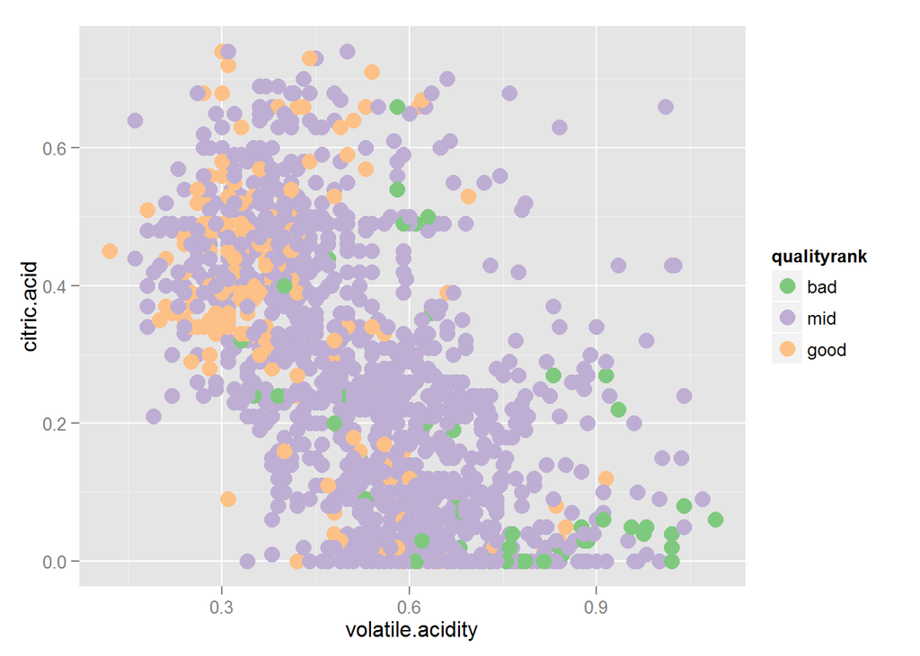

In the figure above you can observe following things:

1. Negative relationship between citric acid and volatile acidity
2. Higher qualities can be mainly found in upper left corner (i.e. lower volatile acidity, higher citric acid)
3. Lower qualities can be found rather by wines with higher volatile acidity and lower citric acid.

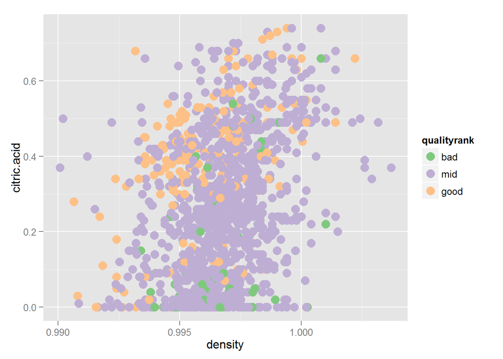

The figure shows again that the wines with better quality have rather higher amount of citric acid. Moreover there seems to be positive relationship between citric acid and density. Finally, it seems that given certain density level the quality is increasing in citric acid.

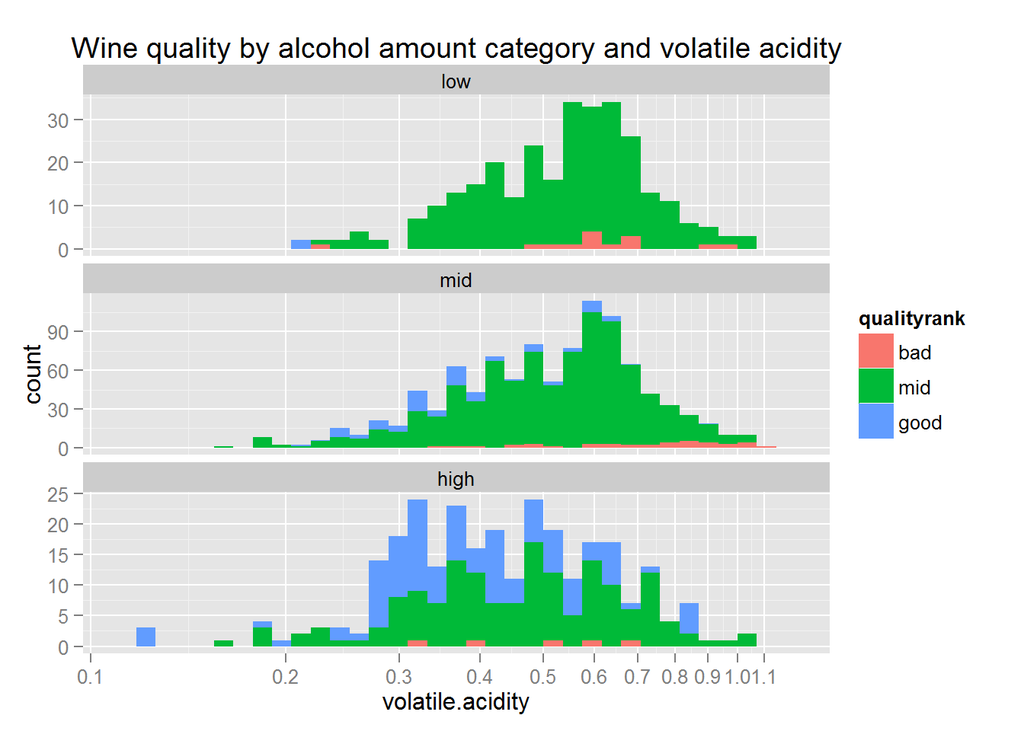

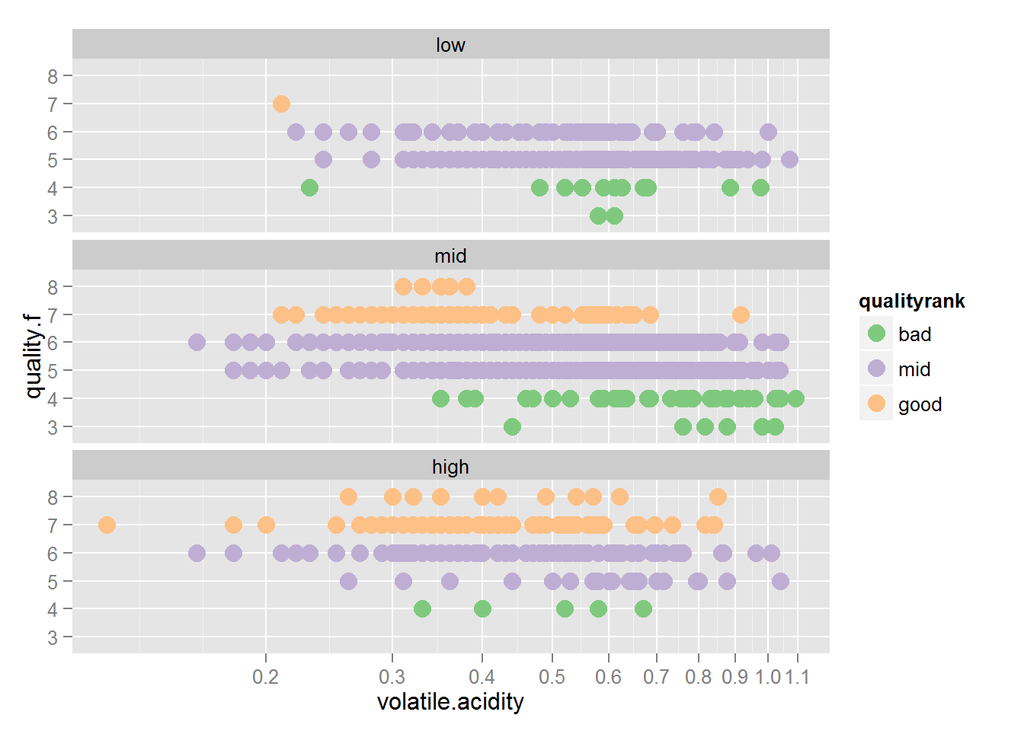

The figures illustrate the strong impact of alcohol on quality. By lower amount of alcohol (< 9.5 %) there are almost no wines with good quality. Only when the volatile acidity is very low. Moreover, when the alcohol amount is high than it is very hard to find wines with bad quality. In other words, for wines with low amount of alcohol the acidity plays an important role for the quality (the higher acidity the lower quality). For the wines with high amount of alcohol, the acidity doesn’t play that strong role. Alcohol seems to have very strong effect on the quality. In the next picture I examine alcohol, density and their impact on quality.

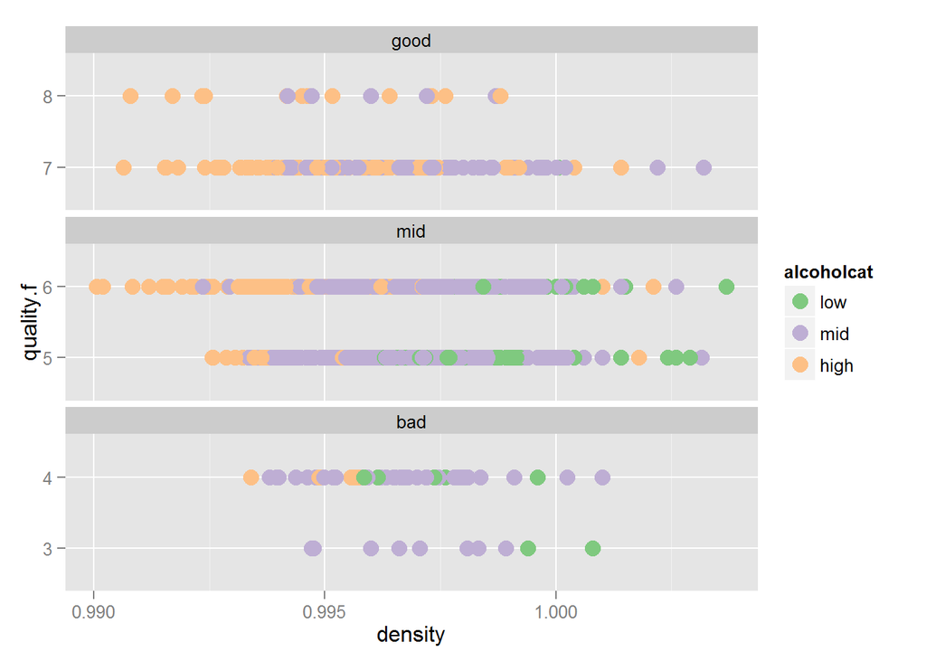

The figure above suggests that the wines with good quality have either mid or high amount of alcohol. Moreover the figures also shows the negative relationship between alcohol and density. Wines with lower density seem to have higher amount of alcohol. Finally, I found interesting that wines with bad quality doesn’t seem to have neither too low nor too large density.

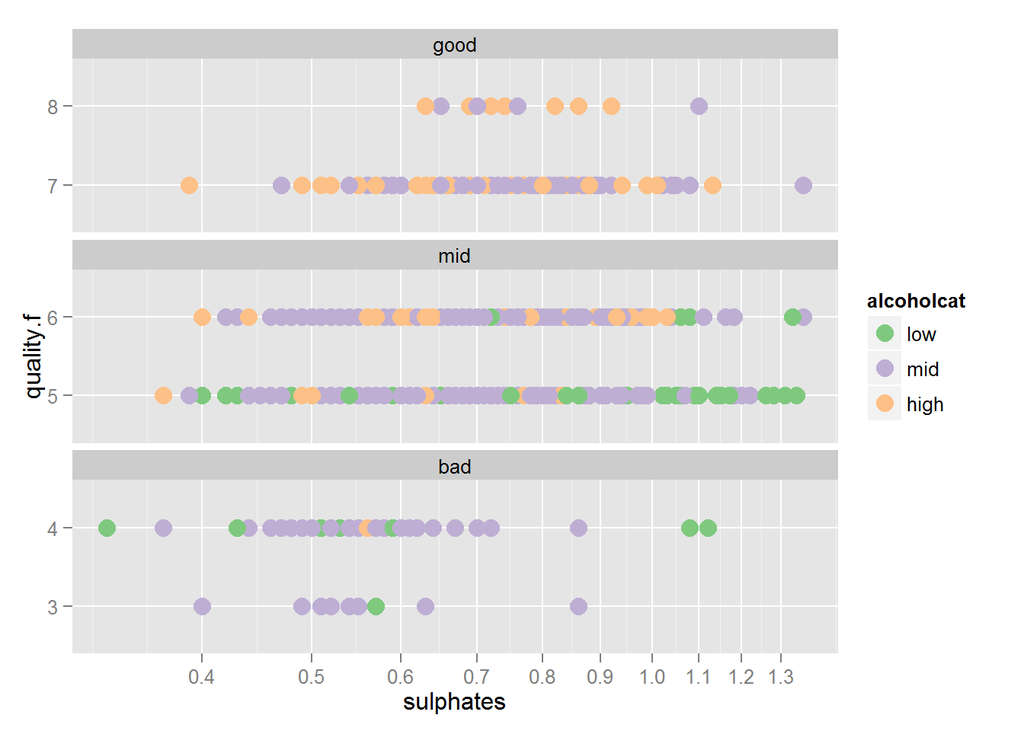

```
## : bad
## : low
##    Min. 1st Qu.  Median    Mean 3rd Qu.    Max.
##  0.3300  0.4925  0.5500  0.7043  0.6225  2.0000
## --------------------------------------------------------
## : mid
## : low
##    Min. 1st Qu.  Median    Mean 3rd Qu.    Max.
##  0.4000  0.5400  0.5900  0.6495  0.6700  1.5600
## --------------------------------------------------------
## : good
## : low
##    Min. 1st Qu.  Median    Mean 3rd Qu.    Max.
##    0.84    0.84    0.84    0.84    0.84    0.84
## --------------------------------------------------------
## : bad
## : mid
##    Min. 1st Qu.  Median    Mean 3rd Qu.    Max.
##  0.3700  0.4900  0.5500  0.5589  0.6000  0.8600
## --------------------------------------------------------
## : mid
## : mid
##    Min. 1st Qu.  Median    Mean 3rd Qu.    Max.
##  0.3900  0.5500  0.6100  0.6478  0.7100  1.9800
## --------------------------------------------------------
## : good
## : mid
##    Min. 1st Qu.  Median    Mean 3rd Qu.    Max.
##  0.4700  0.6650  0.7400  0.7562  0.8300  1.3600
## --------------------------------------------------------
## : bad
## : high
##    Min. 1st Qu.  Median    Mean 3rd Qu.    Max.
##   0.560   0.560   0.560   0.572   0.560   0.620
## --------------------------------------------------------
## : mid
## : high
##    Min. 1st Qu.  Median    Mean 3rd Qu.    Max.
##  0.3700  0.5500  0.6200  0.6403  0.7200  1.0300
## --------------------------------------------------------
## : good
## : high
##    Min. 1st Qu.  Median    Mean 3rd Qu.    Max.
##  0.3900  0.6400  0.7400  0.7309  0.8125  1.1300
```

The figure suggest that given the amount of alcohol, the quality is increaing in the amount of sulphates. It also shows the strong impact of alcohol on quality. When the amount of alcohol is high, the amount of sulphates is not that important. I.e. wines with smaller amount of sulphates have good quality.

Finally, I estimate an model to predict the quality of the red wine.

[output not shown]

```
##
## Calls:
## m1: polr(formula = quality.f ~ alcohol, data = data)
## m2: polr(formula = quality.f ~ alcohol + log10(volatile.acidity),
##     data = data)
## m3: polr(formula = quality.f ~ alcohol + log10(volatile.acidity) +
##     log10(fixed.acidity), data = data)
## m4: polr(formula = quality.f ~ alcohol + log10(volatile.acidity) +
##     log10(fixed.acidity) + total.sulfur.dioxide, data = data)
## m5: polr(formula = quality.f ~ alcohol + log10(volatile.acidity) +
##     log10(fixed.acidity) + total.sulfur.dioxide + log10(sulphates),
##     data = data)
## m6: polr(formula = quality.f ~ alcohol + log10(volatile.acidity) +
##     log10(fixed.acidity) + total.sulfur.dioxide + log10(sulphates) +
##     log10(chlorides), data = data)
##
## ====================================================================================
##                             m1        m2        m3        m4        m5        m6
## ------------------------------------------------------------------------------------
## alcohol                   1.010***  0.924***  0.963***  0.924***  0.901***  0.848***
##                          (0.053)   (0.054)   (0.055)   (0.056)   (0.057)   (0.058)
## 3|4                       5.036***  5.278***  7.737***  6.758***  4.544***  5.912***
##                          (0.611)   (0.622)   (0.892)   (0.927)   (0.967)   (1.026)
## 4|5                       6.916***  7.178***  9.636***  8.650***  6.443***  7.812***
##                          (0.538)   (0.551)   (0.844)   (0.881)   (0.923)   (0.985)
## 5|6                      10.262*** 10.684*** 13.152*** 12.199*** 10.102*** 11.486***
##                          (0.545)   (0.561)   (0.854)   (0.888)   (0.924)   (0.989)
## 6|7                      12.766*** 13.399*** 15.896*** 14.955*** 12.946*** 14.355***
##                          (0.589)   (0.610)   (0.895)   (0.926)   (0.958)   (1.025)
## 7|8                      15.640*** 16.371*** 18.869*** 17.929*** 15.966*** 17.391***
##                          (0.652)   (0.674)   (0.941)   (0.970)   (1.000)   (1.065)
## log10(volatile.acidity)            -4.436*** -4.051*** -4.034*** -3.466*** -3.214***
##                                    (0.356)   (0.367)   (0.368)   (0.375)   (0.380)
## log10(fixed.acidity)                          2.401***  2.112***  1.344*    1.766**
##                                              (0.614)   (0.619)   (0.629)   (0.639)
## total.sulfur.dioxide                                   -0.006*** -0.007*** -0.007***
##                                                        (0.002)   (0.002)   (0.002)
## log10(sulphates)                                                  4.727***  5.448***
##                                                                  (0.564)   (0.594)
## log10(chlorides)                                                           -1.631***
##                                                                            (0.406)
## ------------------------------------------------------------------------------------
## Aldrich-Nelson R-sq.         0.210     0.269     0.274     0.279     0.302     0.307
## McFadden R-sq.               0.112     0.156     0.160     0.164     0.183     0.187
## Cox-Snell R-sq.              0.233     0.308     0.315     0.321     0.352     0.358
## Nagelkerke R-sq.             0.257     0.340     0.347     0.354     0.388     0.395
## Likelihood-ratio           423.954   589.543   604.919   619.776   692.792   709.020
## p                            0.000     0.000     0.000     0.000     0.000     0.000
## Log-likelihood           -1682.248 -1599.454 -1591.766 -1584.337 -1547.830 -1539.715
## Deviance                  3364.496  3198.907  3183.532  3168.675  3095.659  3079.430
## AIC                       3376.496  3212.907  3199.532  3186.675  3115.659  3101.430
## BIC                       3408.759  3250.547  3242.549  3235.069  3169.431  3160.579
## N                         1599      1599      1599      1599      1599      1599
## ====================================================================================
```

# Multivariate Analysis

### Talk about some of the relationships you observed in this part of the investigation. Were there features that strengthened each other in terms of looking at your feature(s) of interest?

The figures in this section indicated that the amount of alcohol is the main driver for red wine quality. The larger the amount of alcohol is the better the quality of the wine is. For example, there are almost no good quality wines with alcohol amount lower than 9.5 %. It was interesting to see that for wines with lower amount of alcohol other features plays also important role for the quality. E.g. by wines with low alcohol amount the volatile acidity has negative impact on quality. By wines with higher alcohol amount the impact of other variables seems to diminish.

### OPTIONAL: Did you create any models with your dataset? Discuss the strengths and limitations of your model.

The McFadden R-Sq. is 0.187 indicating that the model is not that bad but there is definitely room to improve. Usually the values between 0.2 and 0.4 are seen as very good fit (Louviere et al (2000)).

# Final Plots and Summary

### Plot One

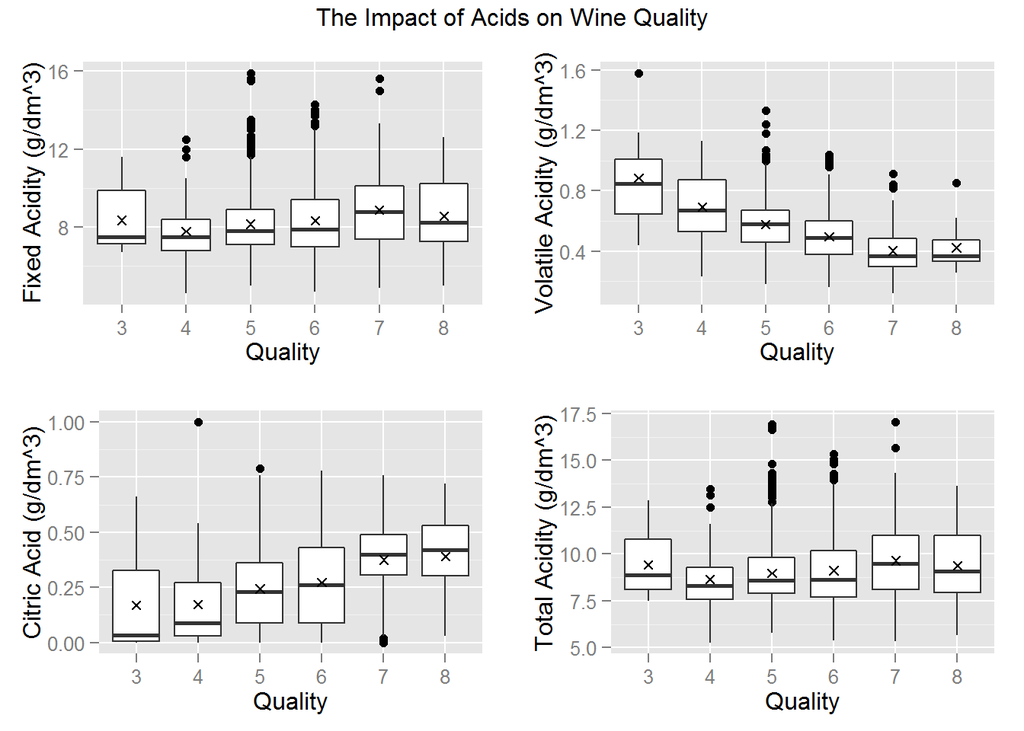

### Description One

These subplots illustrate the impact of different types of acidity on wine quality. While the volatile acidity negatively affects the wine quality, the coorelation between citric acid and quality is pretty strong and positive. Fixed acidity has a smaller positive impact on the quality. Moreover, you can see that the fixed acidity is main driver of all acidities and therefore the relationship between total acidity and quality looks very similar to the relationship observed between fixed acidity and quality. Therefore, by considering only total acidity in the model, we would loose a valuable insight (i.e. the negative correlation between volatile acid and quality).

### Plot Two

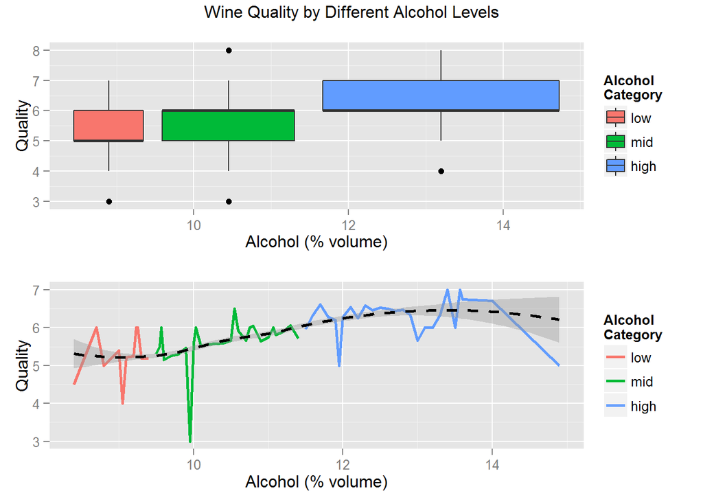

### Description Two

The analysis showed that the alcohol is the main driving force behind the wine quality. Therefore I decided to create a plot in this section which demonstrates the impact of alcohol on wine quality. The first figure is a boxplot which shwos the distribution of quality by different alcohol levels. The later figure illustrates the development of quality mean by different alcohol amounts. The dashed curve is loess curve presenting the relationship. Both figures suggest that in general higher alcohol content is connected with higher quality. However, there are also some outliers signaling that there are probably another factors influencing the quality.

### Plot Three

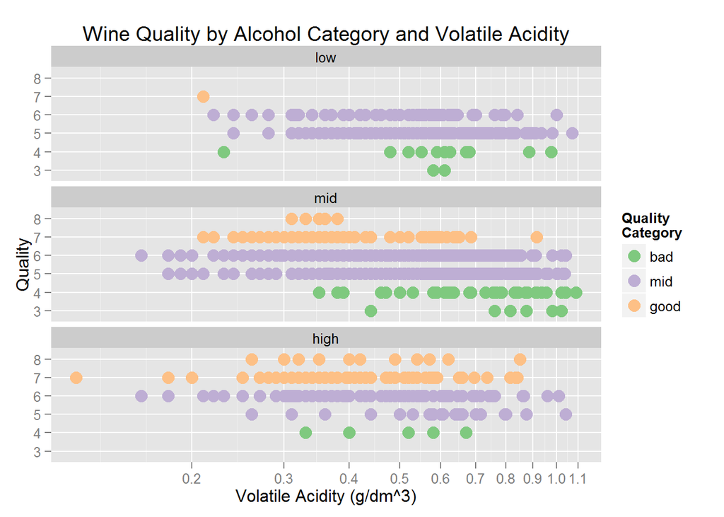

### Description Three

# Reflection

In this document I explored the key factors that drive the quality of red wine. Based on the exploratory data analysis you saw that the alcohol amount is the most important factor driving the red wine quality. In general, the higher alcohol amount is the higher quality is. The other factors, which might contribute to predict red wine quality, are volatile acidity (-), sulphates (+) and chlorides (-).

Further models (e.g. random forest) with the same data could be done to see whether the findings could be confirmed. Moreover, as the used model showed, there might be additional variables influencing the wine quality. The explonatory power of the model was not so strong. Therefore, it might be useful to find additional data, which might have an impact on the quality (e.g. different weather conditions). It would be also useful to have dataset with wines from different regions.